# Presenting information with graphs

The United Nations Whitepaper “Making Data Meaningful Part 2: A guide to presenting statistics United Nations Economic Commission for Europe”, available at http://www.unece.org/fileadmin/DAM/stats/documents/writing/MDM_Part2_English.pdf , has detailed best practices for graphs. Here are some of the key points with commentary:

- Optical illusions exist. Try to avoid them, try to make the data show itself objectively.
- Include zero in the numerical axis when it’s a natural minimum. (unemployment rate, % of a group that is female, cost per watt).
- Include both sides of error bars, and explain what the error bars mean in your graphs.

The best practice is to have error bars represent a confidence interval (e.g. 95%). Not everyone adheres to this best practice; in some graphs, error bars represent standard error, which is why it’s important to be clear about what the errors bars in your graphs mean.

- Consider accessibility in your colour choices.

For example, it’s a bad idea to have a graph that requires the viewer to be able to see the difference between red and green. Nearly 10% of men are red-green colour blind. One method is redundacy: use a red solid line and a green dashed line. An additional benefit of being colour-blind accessible is technological accessibility; your graphs will be readable even when they are printed on greyscale paper or displayed on an e-reader. The blog post at https://venngage.com/blog/color-blind-friendly-palette/ outlines some other ways to make your graphs more accessible.

- Consider accessibility in general. Avoid, when possible, small-size fonts or unusual fonts, digital elements that will make the graph harder to understand in print or other computers, or complicated language.
- Limit the amount of information on a graph to avoid it being a mess.
- Keep your labels consistent (number vs. rate). This guide, “How to Present Statistical Results”, found at http://agostontorok.github.io/public/files/stat02.pdf , is an excellent resource on annotating statistical results on graphs.
- A bar graph (categorical) has gaps between the bars. A histogram (numerical) does NOT.
- Arrange categories from highest to lowest when it makes sense.
- Include guiding lines for scale when possible. Don’t make people trace things with their fingers. (ggplot does this by default)
- If there is a big gap between the data and zero, use an axis break.

An axis break is some visual marker along an axis to show that some range of a numeric variable is ‘skipped’. It’s assumed that there is nothing of interest worth plotting in the skipped range. User Smallman12q of the Wikimedia Commons gives the following example markers for axis breaks:

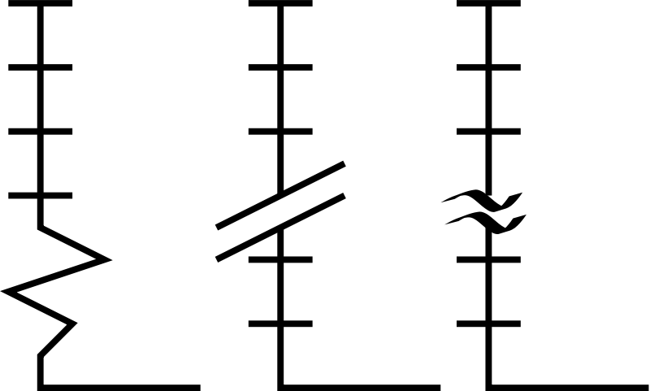

Look for style guides put out by governments and research journals because they have a stake in the quality of the work that uses those guidelines, such as:

- Experimental design and analysis and their reporting: new guidance for publication in BJP Michael J Curtis et al. British Journal of Pharmacology (2015), found at https://bpspubs.onlinelibrary.wiley.com/doi/abs/10.1111/bph.12856
- Data analysis and presentation, Statistics Canada, found at https://www150.statcan.gc.ca/n1/pub/12-539-x/2009001/analysis-analyse-eng.htm

These guides have a common theme: Explain what you’re doing, assume a reader will try to redo the same analysis. What do they need to know in order to do it the same way you did?

Be consistent.

Be exact.

The UN (United Nations) isn’t the only source of quality graphing guides. Consider this guide from the Australian government, found at http://www.qgso.qld.gov.au/about-statistics/presentation/presenting-stat-info-graphs.pdf

Specifically, consider this chart from the guide:

## Example 1:

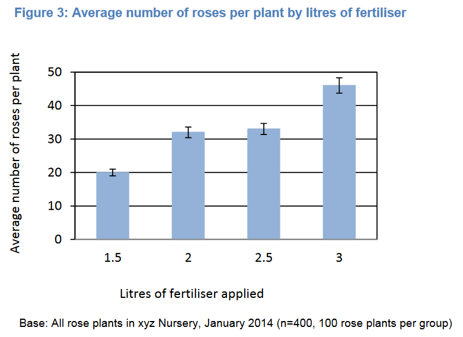

Comments: - Guide lines (horizontal lines). - Error bars actually represent confidence intervals. - Not too much information. - Self-contained.

But not all graph guides are useful. The following graph, Example 2, comes from the guide found at, http://abacus.bates.edu/~ganderso/biology/resources/writing/HTWstats.html , and there are several things wrong with it.

## Example 2:

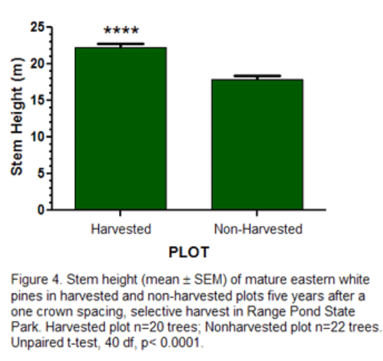

Issues: - No guiding lines. - Only two bars, is a bar graph necessary? - Overwhelming amount of text. (All of this necessary?) - Error bars only go in one direction. - What do these four stars means? **** (Significance of one group? Of a comparison?) The caption says it’s an unpaired t-test, a comparison between two groups, but the location of the **** implies that it’s only to do with one group.

- Error bars are *not* confidence intervals, they show standard error of the mean.

## Example 3:

[figure not shown]

Problems: - This bar graph does not have a labelled y-axis. - The axis starts around 100 M instead of zero. This magnifies the apparent difference between ‘people on welfare’ and ‘people with a full time job’. - There are only two pieces of data here. Text would have been enough. - The graph does not show people with part time jobs, and apparently includes children and retired people as ‘people on welfare’. This graph describes 210 million people out of 300 million in the US.

Solutions: - A pie chart showing the breakdown of people without jobs, with part time jobs, and with full time jobs as a proportion of the US population. - A simple sentence stating “108.6 million people are on welfare, while 101.7 million have full time jobs.” - A bar chart with a labelled y-axis that starts from zero, or at least contains some space and a break at the bottom. - Remove the confusing green gears background. - Remove the title entirely - Add guide lines.

## Example 4:

[figure not shown]

Problems: - It is difficult to connect a certain part of each trend line to a particular year. - The scale for property crime is in ‘thousands per 100,000 people’ while the others are in ‘per 100,000 people’. This implies, at a glance, that there are more murders than property crimes.

Solutions: - Add vertical guidelines every 5 or 10 years. - Mark the crime rates in 1980 and in 2015, or the percentage increase or decrease. - Change the scale of property crimes to number per 100,000 people. - Change the sub-title from ‘rate per 100,000 people’ to ‘number of annual cases per 100,000 people’.

## Example 5:

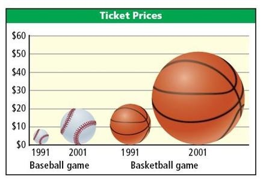

Problems: - People make comparisons based on AREA, not on height, so this graph implies that a x2 increase is actually a x4 increase. (2 times the height and width takes up 4 times the visual area) - Only 4 numbers of information, this might be better as text.

Solution: - Make this a bar graph instead of using cute icons.

## Example 6:

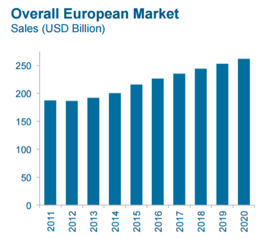

Problems: - Lack of guidelines make it hard to see the magnitude of the changes. - Large spaces between bars make it harder to read than necessary. - Some years are projections / predictions / forecast but don’t say so. - US Dollars in what year?

Solutions: - Use a longer time frame? - May want to consider an axis break.

## Example 7

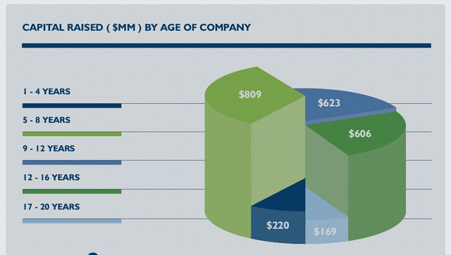

Solutions: - Use a 2-D pie chart! - Instead of relying on colours, label the categories.

## Example 8

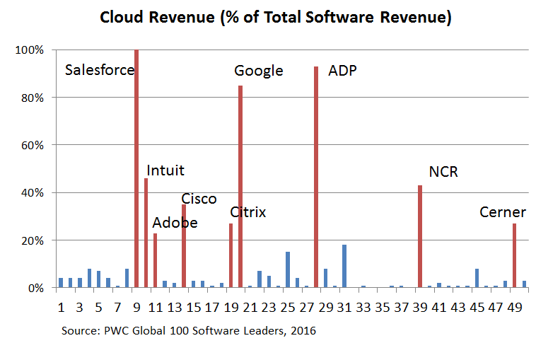

Problems: - Unclear x axis (rank of company by size / market capital). - Unclear what revenue counts as ‘cloud revenue’. - Unclear why some companies are in blue. - Some labels are overlapping the bars.

Solutions: - This could be better as a table, with only the labelled companies. Such a table might be written like this:

Company Total Sales rank % cloud sales Salesforce 450 million 9 100 Intuit 380 mil 10 45

All others in the top 50 have <20% cloud sales

## Example 9

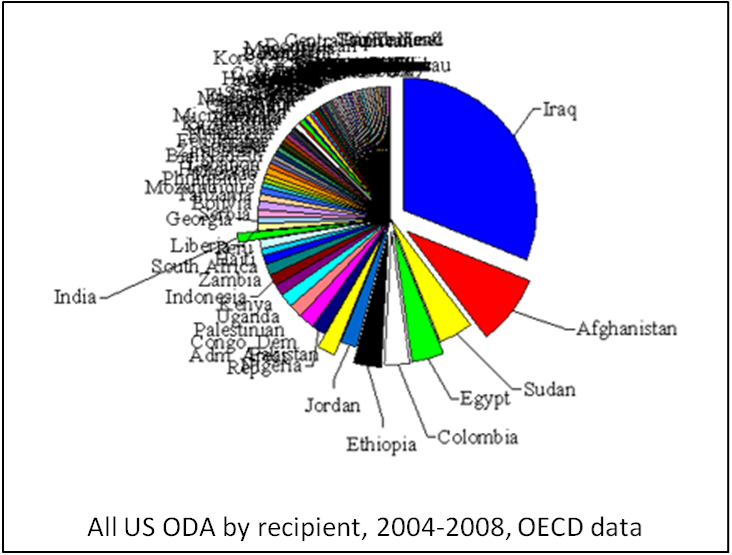

Problems: - There are 200 slices, one for each country. - Some slices are removed from the pie. - There is a massive overlap of labels.

Solutions: - Group together slices. 100 smallest countries put into one slice and label it “other (100 countries)”. - Group together remaining small contrib. by continent or region (other Africa, other Middle East, etc.).

## Example 10

[figure not shown]

Problems: - X-Axis for general population is time (year = 1950 to 2010), but this is completely hidden. - X-Axis inconsistent between musicians and general population. - X-axis is CATEGORICAL, it would be better as a bar chart. - Musicians may belong to multiple categories, so how do you decide? - Does this include only professional musicians? Casual music fans / producers.

Solutions: Use a bar chart. Trash this entirely, because the premise doesn’t make sense without a *lot* of clarification.